# Regresiones lineales, predictores categóricos y representación gráfica

2021-08-13

# 0. Objetivo de la práctica

Entonces, en esta práctica aprenderemos trabajar las **regresiones lineales**, también trabajaremos los **predictores categóricos** y finalmente veremos como **representarlos mediante gráficos y tablas**.

# 1. Recursos del práctico

En este práctico utilizamos los **datos** procesados de la [**Encuesta Suplementaria de Ingresos (ESI) 2020**](https://www.ine.cl/estadisticas/sociales/ingresos-y-gastos/encuesta-suplementaria-de-ingresos).Recuerden **siempre** consultar el [**libro códigos**](https://www.ine.cl/docs/default-source/encuesta-suplementaria-de-ingresos/bbdd/manual-y-gu%C3%ADa-de-variables/2020/personas-esi-2020.pdf?sfvrsn=f196cb4e_4) antes de trabajar datos.

# 2. Librerías a utilizar

Cargaremos los paquetes con `pacman` [revisar práctico 3](https://learn-r-udp.netlify.app/example/03-practico/)

```r
pacman::p_load(sjmisc,
               sjPlot,
               tidyverse,
               magrittr)
```

# 3. Importar datos

Una vez cargado los paquetes a utilizar, debemos cargar los datos procesados.

```r
load("output/data/datos_proc.RData")
```

## Explorar datos

Es relevante explorar los datos que utilizaremos, cómo están previamente procesados ¡no sabemos con que variables estamos trabajando!

```r
names(datos_proc)
```

```
## [1] "ingresos"  "educacion" "sexo"      "edad"
```

```r
head(datos_proc)
```

```
## # A tibble: 6 x 4
##   ingresos                                             educacion      sexo  edad
##      <dbl>                                             <dbl+lbl> <dbl+lbl> <dbl>
## 1  320421. 6 [Educación técnica (Educación superior no universi~ 2 [Mujer]    29
## 2  750000  7 [Educación universitaria]                           2 [Mujer]    30
## 3  900000  7 [Educación universitaria]                           2 [Mujer]    43
## 4       0  5 [Educación secundaria]                              2 [Mujer]    15
## 5       0  3 [Educación primaria (nivel 1)]                      1 [Hombr~    11
## 6       0  5 [Educación secundaria]                              2 [Mujer]    62
```

Ahora sabemos que trabajaremos con `"ingresos"`, `"educacion"`, `"sexo"` y `"edad"`. Ahora inclusive podemos repasar lo visto en el [práctico anterior](https://learn-r-udp.netlify.app/example/04-practico/) y explorar nuestros datos con `sjPlot::view_df()`

Data frame: datos_proc

| ID | Name | Label | Values | Value Labels |
| --- | --- | --- | --- | --- |
| 1 | ingresos | Total ingresos sueldos y salarios | *range: 0.0-9312239.1* |  |
| 2 | educacion | Clasificación Internacional de Nivel Educacional (CINE) | 1 2 3 4 5 6 7 8 9 999 | Nunca estudió Educación preescolar Educación primaria (nivel 1) Educación primaria (nivel 2) Educación secundaria Educación técnica (Educación superior no universitaria) Educación universitar… |
| 3 | sexo | Sexo | 1 2 | Hombre Mujer |
| 4 | edad | Edad de la persona | *range: 0-106* |  |

Perfecto, podemos ver las variables que tenemos y sus categorías de respuesta, pero antes de continuar, es importante conocer los tipos de variables a usar, para eso pueden ir al mini tutorial de [**tipos de variables y ejemplos**](https://learn-r-udp.netlify.app/resource/r-datatypes-examples/)

Perfecto! ahora que repasamos los tipos de variables y sabemos que estadísticos son para cada tipo pasaremos al **análisis bivariado**

# 4. Análisis bivariado

Es relevante que previo a la regresión lineal se realicen análisis bivariados, esto pueden encontrarlo con más detalle en el [práctico de descriptivos](https://learn-r-udp.netlify.app/example/04-practico/). En esta ocasión repasaremos con una **tabla de correlación**, **un gráfico de puntos** y **un gráfico de cajas**

## 4.1 Correlación

En esta ocasión generaremos una tabla de correlación entre las variables `ingresos` y `edad`, para eso usaremos la función `tab_corr` de `sjPlot`

Previamente debemos seleccionar las variables a utilizar, ya que no tiene sentido incluir en el análisis variables nominales

```r
datos_proc %>%
select(ingresos, edad) %>%
tab_corr(.,
         triangle = "lower",
         title = "Tabla de correlación",
         encoding = "UTF-8",
         file = "output/figures/tabla4.doc")
```

Tabla de correlación

|  | Total ingresos sueldos y salarios | Edad de la persona |
| --- | --- | --- |
| Total ingresos sueldos y salarios |  |  |
| Edad de la persona | 0.086*** |  |
| Computed correlation used pearson-method with listwise-deletion. |  |  |

Ahora podemos observar que efectivamente existe una correlación entre los ingresos y la edad.

## 4.2 Gráfico de nube de puntos (scatter)

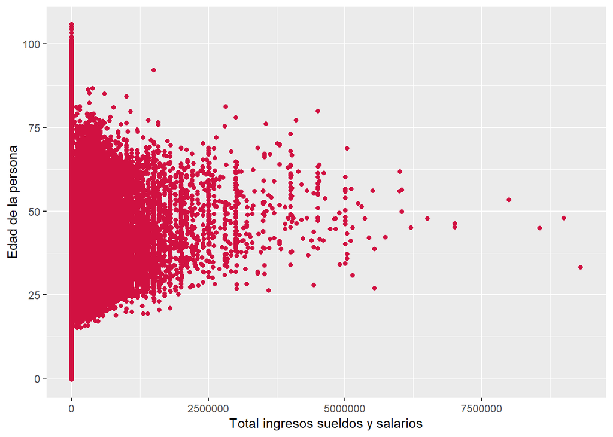

```r
datos_proc %>%
   plot_scatter(., ingresos, edad)
```

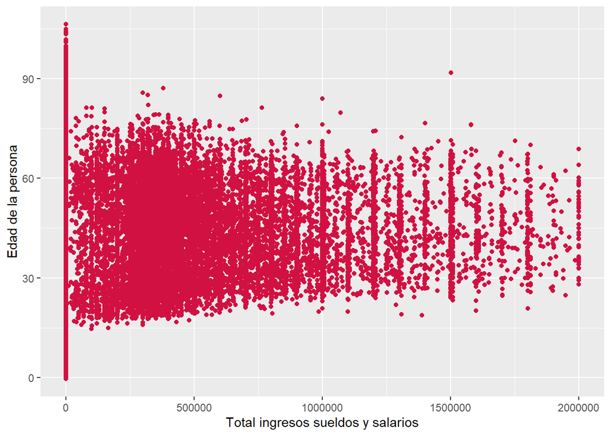

```r
datos_proc %>%  filter(ingresos <= 2000000) %>%
   plot_scatter(., ingresos, edad)
```

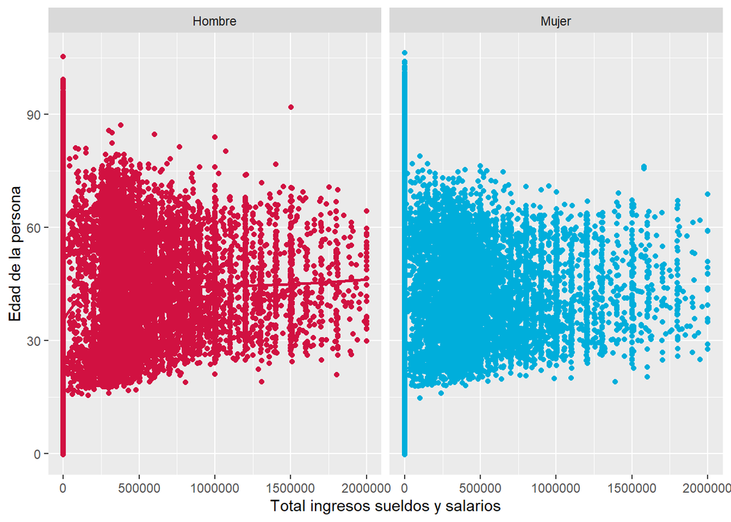

```r
datos_proc %>%  filter(ingresos <= 2000000) %>%
    plot_scatter(., ingresos, edad, sexo,
             fit.grps = "loess", grid = TRUE)
```

## 4.3 Gráfico de cajas

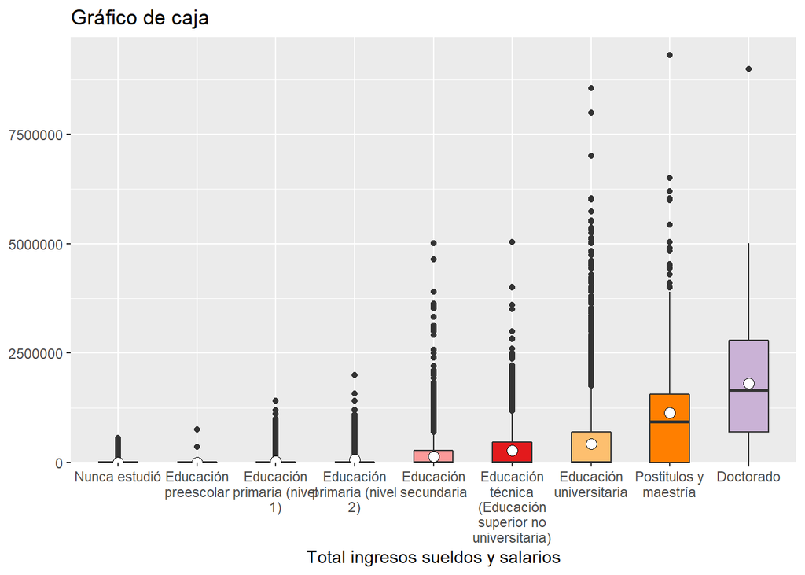

```r
plot_grpfrq(datos_proc$ingresos, datos_proc$educacion,
            title = "Gráfico de caja",
             type = c("boxplot"))
```

Además, se puede incorporar una tercera variable, en este caso lo haremos con la variable `sexo`

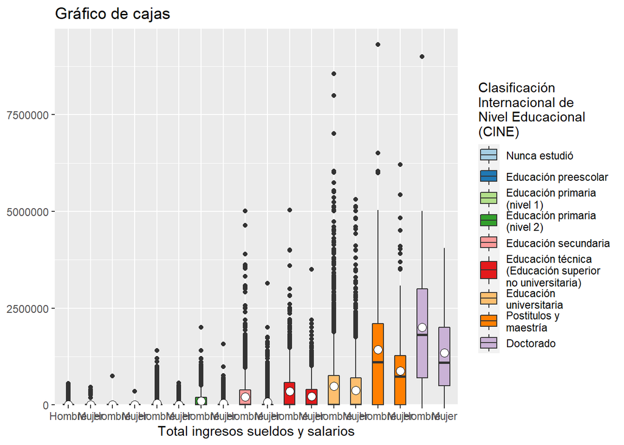

```r
plot_grpfrq(datos_proc$ingresos, datos_proc$educacion, intr.var = datos_proc$sexo,
            title = "Gráfico de cajas",
            type = "box")
```

Ahora que observamos como se comportan nuestras variables iremos a la regresión lineal

# 5. Modelo de regresión

Previo a eso recordemos que la fórmula de la regresión lineal simple es:

$$\begin{equation}
\widehat{Y}=b_{0} +b_{1}X
(\#eq:reg)
\end{equation}$$

Mientras que en la regresión lieal múltiple es:

$$\begin{equation}
\widehat{Y}=b_{0} +b_{1}X +b_{2}X +b_{x}X
(\#eq:reg)
\end{equation}$$

Donde

- $\widehat{Y}$ es el valor estimado/predicho de $Y$
- $b_{0}$ es el **intercepto** de la recta (el valor de Y cuando X es 0)
- $b_{1}$ y $b_{2}$ son los **coeficiente de regresión**, que nos dice cuánto aumenta Y por cada punto que aumenta X (pendiente)

Les mostramos esto porque de la misma forma se diferencian ambos procedimientos en R

Para la regresión lineal simple se utiliza la siguiente estructura:

```
objeto <- lm(dependiente ~ independiente, data=datos)
```

Mientras que para la regresión lineal múltiple, sólo se añaden más variables

```
objeto <- lm(dependiente ~ independiente1 + independiente 2 + independientex, data=datos)
```

Ahora en nuestros datos queda de la siguiente manera

```r
reg_1 <-lm((ingresos ~ edad), data = datos_proc)
reg_1
```

```
##
## Call:
## lm(formula = (ingresos ~ edad), data = datos_proc)
##
## Coefficients:
## (Intercept)         edad
##      102548         1530
```

pero el problema es que al observar el objeto creado, no es muy presentable para informes, por eso usaremos la función `tab_model` de `sjPlot`

```r
sjPlot::tab_model(reg_1, show.ci=FALSE,  encoding = "UTF-8", file = "output/figures/reg1_tab.doc")
```

|  | Total ingresos sueldos y salarios |  |
| --- | --- | --- |
| Predictors | Estimates | p |
| (Intercept) | 102548.34 | **<0.001** |
| Edad de la persona | 1529.88 | **<0.001** |
| Observations | 71935 |  |
| R<sup>2</sup> / R<sup>2</sup> adjusted | 0.007 / 0.007 |  |

Ahora queremos incorporar las demás variables al modelo, para lo haremos de ña siguiente manera

# predictores categoricos

Previo a esto hay que recordar que estos predictores no son contínuos, y tambien debemos recordarselo a la base de datos

```r
datos_proc$sexo <- as_factor(datos_proc$sexo)
datos_proc$educacion <- as_factor(datos_proc$educacion)
```

Perfecto ahora si podemos añadir predictores categoricos a nuestra regresión lineal

```r
reg_2 <-lm((ingresos ~ edad + educacion), data = datos_proc)
reg_3 <-lm((ingresos ~ edad + educacion + sexo), data = datos_proc)
```

Pero que pasa si queremos incluir todos los modelos creados en una sóla tabla, para eso usaremos nuevamente la función `tab_model` de `sjPlot`

```r
sjPlot::tab_model(list(reg_1, reg_2, reg_3), # los modelos estimados
  show.ci=FALSE, # no mostrar intervalo de confianza (por defecto lo hace)
  p.style = "stars", # asteriscos de significación estadística
  dv.labels = c("Modelo 1", "Modelo 2", "Modelo 3"), # etiquetas de modelos o variables dep.
  string.pred = "Predictores", string.est = "β", encoding = "UTF-8", file = "output/figures/reg1_tab.doc") # nombre predictores y símbolo beta en tabla
```

Modelo 1

Modelo 2

Modelo 3

Predictores

(Intercept)

102548.34 ***

-14339.91 *

30913.24 ***

Edad de la persona

1529.88 ***

993.59 ***

1113.22 ***

8700.05

-3662.18

-4237.43

42577.92 ***

38425.34 ***

112225.57 ***

111969.45 ***

educacion: Educación  
técnica (Educación  
superior no  
universitaria)

242074.24 ***

246489.93 ***

401092.50 ***

401198.02 ***

1102819.14 ***

1102570.64 ***

educacion: Doctorado

1766234.95 ***

1744319.18 ***

Sexo: Mujer

-93574.27 ***

Observations

71935

71346

71346

R<sup>2</sup> / R<sup>2</sup> adjusted

0.007 / 0.007

0.189 / 0.189

0.202 / 0.202

- p<0.05 ** p<0.01 *** p<0.001

Visualización de hipótesis

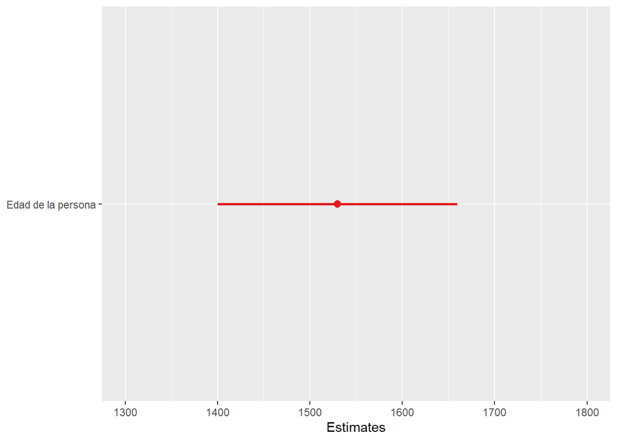

```r
sjPlot::plot_model(reg_1, ci.lvl = c(0.95), title = "",vline.color = "grey",line.size = 1)
```

Lo que nos muestra este gráfico es el valor del coeficiente en el punto, y en las líneas que salen del punto se extienden según su intervalo de confianza. De acuerdo a las reglas de inferencia en regresión, lo que estamos contrastando es que el valor de este coeficiente es distinto de 0 en la población, con un cierto valor de probabilidad. Por lo tanto, si agregamos un intervalo de confianza (valores probables) asociado a una probabilidad de error, entonces podemos decir que este coeficiente es estadísticamente distinto de 0 en la población. Y en el gráfico, esto sucede cuando los intervalos no tocan el 0.